# Quantum Fourier Transform

### Introduction

The quantum Fourier transform is a fundamental algorithm in quantum computing that serves as a backbone of many applications in quantum algorithms, such as quantum phase estimation and Shor’s algorithm.

In this notebook, we will state the transform that the quantum Fourier transform implements and how it helps reveal periodic patterns in a quantum state. We will compare the Fourier basis with the computational and Hadamard bases, highlighting how information spreads from local (computational/Hadamard) to global (Fourier) representations.

We will also outline how the algorithm works and discuss its gate complexity: exact QFT circuits use $\mathcal{O}(n^2)$ gates on $n$ qubits, and common approximations can reduce this toward $\mathcal{O}(n\log n)$. In algorithmic settings, the quantum Fourier transform offers a speedup over its classical counterpart.

Finally, we will implement the QFT in PennyLane and conclude with brief remarks.

1. Problem Statement
2. Fourier Basis
3. Visualizations on the Bloch Sphere
4. Implementation of QFT
5. Gate complexity of the exact QFT
6. QFT Approximations
7. Complexity of QFT vs Classical Fourier Transform
8. Mutually Unbiased Bases
9. Example
10. Conclusion

### Appendices

11. Appendix 1: Biography
12. Appendix 2: References and Suggested Readings

### Problem Statement

$$ \DeclareMathOperator{\QFT}{QFT} $$

The QFT is a unitary operation that maps computational basis states to uniform superpositions with phase factors. For example, for a basis state $|x\rangle$,

$$ \QFT(|x\rangle) = \frac{1}{\sqrt{N}} \sum_{y=0}^{N-1} e^{\tfrac{2 \pi i x y}{N}} |y\rangle, $$

where the value of $x$ is now encoded in the relative phases of the amplitudes.

For an arbitrary quantum state $$ |\psi\rangle = \sum\limits_{x=0}^{N-1} a_x |x \rangle $$

where $a_x \in \mathbb{C}$ are the amplitudes in the computational basis, the QFT transforms this into

$$ \QFT \left( |\psi \rangle \right) = \QFT \left( \sum\limits_{x=0}^{N-1} a_x |x\rangle \right) = \sum\limits_{y=0}^{N-1} \left( \frac{1}{\sqrt{N}} \sum\limits_{x=0}^{N-1} a_x e^{\frac{2 \pi i x y}{N}} \right) |y\rangle $$

The new amplitudes $$ b_y = \frac{1}{\sqrt{N}} \sum\limits_{x=0}^{N-1} a_x e^{\frac{2 \pi i x y}{N}} $$ correspond to the discrete Fourier transform (DFT) of the original amplitudes $\{ a_x \} $.

The inverse QFT is also unitary and reverses the effect of the QFT. It maps $|y\rangle$ to:

$$ \QFT^{-1} \left( | y \rangle \right) = \frac{1}{\sqrt{N}} \sum\limits_{x=0}^{N-1} e^{- \frac{2 \pi i x y}{N}} | x \rangle $$

or applied to a general quantum state:

$$ \QFT^{-1} \left( \sum\limits_{y=0}^{N-1} b_y |y\rangle \right) = \sum\limits_{x=0}^{N-1} \left( \frac{1}{\sqrt{N}} \sum\limits_{y=0}^{N-1} b_y e^{-\frac{2 \pi i x y}{N}} \right) | x \rangle. $$

#### Fourier Basis Notation

In quantum computing, there are various bases to choose from, with the computational basis being the canonical choice: ${ |x\rangle }$ where $x \in \{0,1\}^n$. By default in the literature it is implicitly assumed that the quantum state $|x\rangle$ is written in the computational basis; however, in the case where multiple bases are being considered in the same text, then we need to use precise notation to clarify which we mean. For instance, we express $\frac{1}{\sqrt{2}} \left( |0\rangle + |1\rangle \right) $ as $| + \rangle $ by simply expressing the state in the Hadamard basis; however, in this case, the $| + \rangle$ and $| - \rangle$ notation makes it clear that we mean the Hadamard basis. For the Fourier basis, we need to introduce a clear notation. In the literature, it is common to use $|\tilde{x} \rangle$ for states expressed in the Fourier basis. To make things clear, for the remainder of this text, we will use the notation $|x\rangle$ to refer to a quantum state in the computational basis, $|+\rangle$ or $|-\rangle$ to refer to the Hadamard basis, and finally $|x\rangle_{\text{F}}$ or $|\tilde{x}\rangle$ to mean quantum state $|x\rangle$ is expressed in the Fourier basis.

The Fourier basis provides another way of describing a quantum state, defined as follows:

### Fourier Basis

For a space of dimension $N = 2^n$, the Fourier basis is:

$$\mathcal{B}_{\text{Fourier}} = \left\{ |j \rangle \mid |j \rangle = \frac{1}{\sqrt{N}} \sum\limits_{k=0}^{N-1} e^{\frac{2 \pi i j k}{N}} | k \rangle , j = 0,1,\dots, N-1 \right\}$$

or more compactly, by letting $\omega = e^{\frac{2\pi i}{N}}$ be the primitive $N^\text{th}$ root of unity:

$$\mathcal{B}_{\text{Fourier}} = \left\{ |j \rangle \mid |j \rangle = \frac{1}{\sqrt{N}} \sum\limits_{k=0}^{N-1} \omega^{jk} | k \rangle, j = 0,1,\dots, N-1 \right\}.$$

**Claim**. Fourier basis is orthnormal.

**Proof (click to expand)**

**Proof.**

Recall the Fourier basis vectors are defined as:

$$ |j\rangle = \frac{1}{\sqrt{N}} \sum_{k=0}^{N-1} \omega^{jk} |k\rangle $$

where $\omega = e^{2\pi i/N}$.

Thus, the inner product is:

$$ \langle j | j' \rangle = \left( \frac{1}{\sqrt{N}} \sum_{k=0}^{N-1} \omega^{-jk} \langle k| \right) \left( \frac{1}{\sqrt{N}} \sum_{k'=0}^{N-1} \omega^{j'k'} |k'\rangle \right) $$

Expand the product:

$$ = \frac{1}{N} \sum_{k=0}^{N-1} \sum_{k'=0}^{N-1} \omega^{-jk} \omega^{j'k'} \langle k | k' \rangle $$

Since $\langle k | k' \rangle = \delta_{k,k'}$ (the computational basis is orthonormal), this simplifies the double sum:

$$ = \frac{1}{N} \sum_{k=0}^{N-1} \omega^{-jk} \omega^{j'k} $$

Combine the exponents:

$$ = \frac{1}{N} \sum_{k=0}^{N-1} \omega^{(j' - j)k} $$

Now we have two cases:

#### Case 1: $j = j'$

Then $(j' - j) = 0$, and $\omega^0 = 1$ for all $k$.

Thus:

$$ \langle j | j \rangle = \frac{1}{N} \sum_{k=0}^{N-1} 1 = \frac{1}{N} \times N = 1 $$

Thus, the vectors are normalized.

#### Case 2: $j \neq j'$

Here we would like to show that distinct states in the basis are orthogonal, meaning their inner product is zero. This follows directly from the fact that the sum of all $N^{\text{th}}$ roots of unity is zero; that is, $\sum\limits_{k=0}^{N-1} \omega^k = 0$. However, we will provide the argument explicitly for completeness.

$j \neq j' \Rightarrow (j' - j) \neq 0$.

We recognize this sum:

$$ \sum_{k=0}^{N-1} \omega^{(j' - j)k} $$

as a geometric series with common ratio $r = \omega^{j'-j} \neq 1$ (since $\omega^{j'-j}$ is a nontrivial root of unity). The formula for a geometric series is:

$$ \sum_{k=0}^{N-1} r^k = \frac{1-r^N}{1-r} $$

where $r = \omega^{j'-j}$. Since $\omega^N = 1$, we have:

$$ r^N = (\omega^{j'-j})^N = (\omega^N)^{j'-j} = 1^{j'-j} = 1 $$

Thus:

$$ 1 - r^N = 0 $$

and therefore:

$$ \sum_{k=0}^{N-1} \omega^{(j' - j)k} = 0 $$

Therefore:

$$ \langle j | j' \rangle = 0 $$

Thus, the Fourier basis vectors are orthogonal. $\blacksquare$

### Computational and Fourier Basis States for $n=2$ qubits

The computational basis states are:

$$ |0\rangle = [1, 0, 0, 0]^T, \quad |1\rangle = [0, 1, 0, 0]^T, \quad |2\rangle = [0, 0, 1, 0]^T, \quad |3\rangle = [0, 0, 0, 1]^T $$

The Quantum Fourier Transform (QFT) for $|x\rangle$ is defined as:

$$ \text{QFT}(|x\rangle) = \frac{1}{\sqrt{N}} \sum_{k=0}^{N-1} e^{2\pi i x k / N} |k\rangle $$

where $N = 2^n = 4$ and $\omega = e^{2\pi i/4} = i$.

### General $N\times N$ QFT matrix in terms of $\omega$

Let $\omega := e^{2\pi i / N}$. The QFT matrix $F_N$ has entries

$$ (F_N)_{j,k} \;=\; \frac{1}{\sqrt{N}}\,\omega^{\,jk}, \quad j,k \in \{0,1,\dots,N-1\}. $$

So $$ F_N \;=\; \frac{1}{\sqrt{N}} \begin{bmatrix} 1 & 1 & 1 & \cdots & 1 \\ 1 & \omega & \omega^{2} & \cdots & \omega^{N-1} \\ 1 & \omega^{2} & \omega^{4} & \cdots & \omega^{2(N-1)} \\ \vdots & \vdots & \vdots & \ddots & \vdots \\ 1 & \omega^{N-1} & \omega^{2(N-1)} & \cdots & \omega^{(N-1)(N-1)} \end{bmatrix}. $$

In matrix form, the $\QFT$ matrix $F_4$ is

$$ F_4 = \frac{1}{2} \begin{bmatrix} 1 & 1 & 1 & 1 \\ 1 & \omega & \omega^{2} & \omega^{3} \\ 1 & \omega^{2} & \omega^{4} & \omega^{6} \\ 1 & \omega^{3} & \omega^{6} & \omega^{9} \end{bmatrix} = \frac{1}{2} \begin{bmatrix} 1 & 1 & 1 & 1 \\ 1 & i & -1 & -i \\ 1 & -1 & 1 & -1 \\ 1 & -i & -1 & i \end{bmatrix}. $$

The action of $F_4$ on the basis states is:

$$ \begin{aligned} \QFT(|0\rangle) &= \tfrac{1}{2} (|0\rangle + |1\rangle + |2\rangle + |3\rangle), \\ \QFT(|1\rangle) &= \tfrac{1}{2} (|0\rangle + i|1\rangle - |2\rangle - i|3\rangle), \\ \QFT(|2\rangle) &= \tfrac{1}{2} (|0\rangle - |1\rangle + |2\rangle - |3\rangle), \\ \QFT(|3\rangle) &= \tfrac{1}{2} (|0\rangle - i|1\rangle - |2\rangle + i|3\rangle). \end{aligned} $$

Thus, in the Fourier basis, all states become uniform superpositions with specific phases determined by $\omega^{xk}$.

We observe that incrementing a number in Fourier basis leads to more global changes while incrementing in the computational basis is more local and the the more signficant qubits change less frequently.

**Computational Basis (CB) - Localised Information**

For an $n$-qubit register the computational basis states are

$$ \lvert x_{n-1}\,x_{n-2}\dots x_0\rangle, \qquad x_j\in\{0,1\}, $$

encoding the integer

$$ k \;=\; \sum_{j=0}^{n-1} x_j\,2^{\,j}. $$

*Increment $k\mapsto k+1$*

- The least-significant bit (LSB, qubit $0$) flips every step.
- Carries propagate upward until the first $0$ is reached.
- High-index qubits stay unchanged for long stretches.

*Implication:* small numerical changes affect only a few low-index qubits.  
Information is therefore **highly local**.

**Fourier Basis (FB/QFT) - Global Information**

The Quantum Fourier Transform acts as

$$ \QFT \left( \lvert k\rangle \right) \;=\; \frac{1}{2^{\frac{n}{2}}} \sum_{j=0}^{2^{n}-1} e^{\frac{2\pi i k j}{2^{n}}}\, \lvert j\rangle . $$

*Increment $k \mapsto k+1$*

$$ e^{\tfrac{2\pi i (k+1)j}{2^{n}}} \;=\; e^{\tfrac{2\pi i k j}{2^{n}}} \cdot e^{\tfrac{2\pi i j}{2^{n}}}, $$

so every amplitude acquires a different extra phase.  
After an inverse QFT (for Bloch-sphere views) these relative phases rotate all qubits, even the most significant ones.

*Implication:* a unit change in $k$ is felt across the whole register, information is **fully global**, encoded in relative phases.

**Hadamard Basis (HB) - Hybrid**

Applying $H^{\otimes n}$ gives

$$ H^{\otimes n}\lvert x_{n-1}\dots x_0\rangle = \frac{1}{2^{n/2}} \bigotimes_{j=0}^{n-1} \bigl(\lvert0\rangle + (-1)^{x_j}\lvert1\rangle\bigr), $$

where the bitstring $(x_{n-1}\dots x_0)$ encodes the integer

$$ k = \sum_{j=0}^{n-1} x_j \, 2^j. $$

With single-qubit Hadamards,

$$ H\lvert0\rangle=\lvert+\rangle, \qquad H\lvert1\rangle=\lvert-\rangle. $$

*Increment $k \mapsto k+1$*

- Flipping bit $x_j$ changes only qubit $j$ between $\lvert+\rangle$ and $\lvert-\rangle$.
- Small increments therefore perturb mainly the low-index qubits, as in CB.

*Implication:* each qubit still tracks a single binary digit (local), yet every qubit sits on the equator of its Bloch sphere, giving a mild global structure — a **hybrid** between CB and FB.

| Basis | Qubits affected by $k\!\to\!k+1$ | Local / global character | Gate cost from $\lvert0^{\otimes n}\rangle$ |
| --- | --- | --- | --- |
| CB | Few low qubits | Highly local | none |
| HB | Same qubits (X-axis) | Local / hybrid | $n$ single-qubit $H$ |
| FB (QFT) | All qubits | Fully global | $\frac{n(n-1)}{2}$ controlled-phase + $n$ $H$ |

Choosing a basis changes how information is distributed across the register: in the computational and Hadamard bases, each qubit independently tracks one binary digit (local encoding), whereas in the Fourier basis, information is encoded globally in relative phases, which underlies algorithms such as period finding.

### Visualizations on the Bloch Sphere

To see this visually, we plot the two-qubit states in the computational, Hadamard, and Fourier bases on the Bloch sphere. An interesting observation is that in the Fourier basis, each increment of the integer causes all arrows to rotate, so every qubit changes direction. By contrast, in the computational and Hadamard bases, only the least significant bit flips at first. The effect then "trickles up" to more significant qubits, which remain unchanged until carries propagate to them.

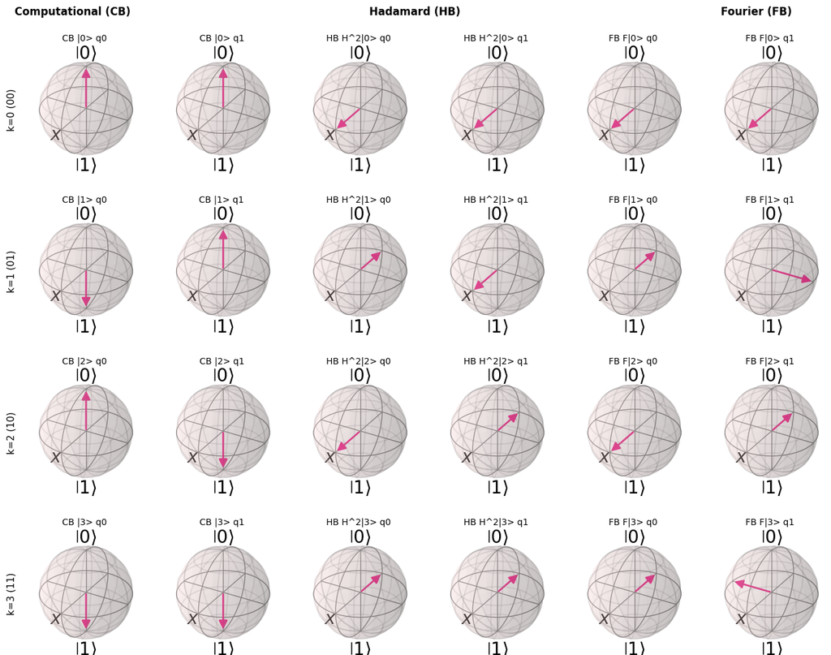

```python
%matplotlib inline

from qiskit import QuantumCircuit
from qiskit.circuit.library import QFT
from qiskit.quantum_info import Statevector, DensityMatrix, partial_trace
from qiskit.visualization.bloch import Bloch
import numpy as np
import matplotlib.pyplot as plt

# -----------------------
# Parameters
# -----------------------
n = 2
N = 2**n
do_swaps = False   # keep False so qubit order remains consistent in QFT

# -----------------------
# Helpers
# -----------------------
def prep_comp_state(k, n):
    """Return Statevector(|k>) and the n-bit string (little-endian qubit order)."""
    qc = QuantumCircuit(n)
    b = format(k, f'0{n}b')
    for idx, bit in enumerate(reversed(b)):  # qubit 0 is LSB in Qiskit
        if bit == '1':
            qc.x(idx)
    return Statevector(qc), b

def prep_fourier_state(k, n, do_swaps=False):
    """Return Statevector(QFT|k>)."""
    qc = QuantumCircuit(n)
    b = format(k, f'0{n}b')
    for idx, bit in enumerate(reversed(b)):
        if bit == '1':
            qc.x(idx)
    qc.append(QFT(n, do_swaps=do_swaps), range(n))
    return Statevector(qc)

def prep_hadamard_state(k, n):
    """Return Statevector(H^{\\otimes n}|k>)."""
    qc = QuantumCircuit(n)
    b = format(k, f'0{n}b')
    for idx, bit in enumerate(reversed(b)):
        if bit == '1':
            qc.x(idx)
    qc.h(range(n))
    return Statevector(qc)

def single_qubit_bloch_vectors(state, n):
    """
    Compute Bloch vectors (x,y,z) for each qubit of an n-qubit pure state.
    Returns a list of length n; index j corresponds to qubit j (Qiskit little-endian).
    """
    rho = DensityMatrix(state)  # convert statevector -> density matrix
    vecs = []
    for q in range(n):
        trace_out = [i for i in range(n) if i != q]
        rho_q = partial_trace(rho, trace_out).data  # 2x2 reduced density matrix

        # Bloch components: x = 2 Re(r01), y = -2 Im(r01), z = r00 - r11
        r00 = np.real(rho_q[0, 0])
        r11 = np.real(rho_q[1, 1])
        r01 = rho_q[0, 1]
        x = 2.0 * np.real(r01)
        y = -2.0 * np.imag(r01)
        z = r00 - r11
        vecs.append((x, y, z))
    return vecs

def draw_bloch_on_axis(ax3d, vec, title=None):
    """Render a Bloch sphere, keep only $x$, |0>, |1> labels (with padding),
    and raise the subplot title to avoid overlap."""

    b = Bloch(axes=ax3d)
    b.vector_width = 2
    b.point_color = ["#d62728"]
    b.add_vectors(vec)
    b.render()

    # Keep only x, |0>, |1>; hide y. Add padding to |0> and |1>.
    for txt in list(ax3d.texts):
        label = txt.get_text()
        if label in ("$y$", "$z$"):
            txt.set_visible(False)
        elif label == r"$\left|0\right>$":
            p = txt.get_position_3d()
            txt.set_position_3d((p[0], p[1], p[2] + 0.10))  # push |0> higher
        elif label == r"$\left|1\right>$":
            p = txt.get_position_3d()
            txt.set_position_3d((p[0], p[1], p[2] - 0.30))  # push |1> lower

    if title:
        ax3d.set_title(title, fontsize=10, y=2, pad=1)

# -----------------------
# Build the composite figure with 3D axes (CB | HB | FB)
# -----------------------
fig = plt.figure(figsize=(3*n*2.7, N*2.9))  # a touch larger for padding
axes = np.empty((N, 3*n), dtype=object)

# Create a grid of 3D subplots
for r in range(N):
    for c in range(3*n):
        idx = r*(3*n) + c + 1
        axes[r, c] = fig.add_subplot(N, 3*n, idx, projection='3d')

# Extra spacing between rows/cols
plt.subplots_adjust(hspace=0.45, wspace=0.25, top=0.92)

block_titles = ["Computational (CB)", "Hadamard (HB)", "Fourier (FB)"]  # HB middle, FB last

for k in range(N):
    comp_sv, bstr = prep_comp_state(k, n)
    four_sv = prep_fourier_state(k, n, do_swaps=do_swaps)
    had_sv  = prep_hadamard_state(k, n)

    comp_vecs = single_qubit_bloch_vectors(comp_sv, n)
    four_vecs = single_qubit_bloch_vectors(four_sv, n)
    had_vecs  = single_qubit_bloch_vectors(had_sv,  n)

    for q in range(n):
        # Column indices: CB block [0..n-1], HB block [n..2n-1], FB block [2n..3n-1]
        c_cb  = 0*n + q
        c_hb  = 1*n + q   # HB in the middle
        c_fb  = 2*n + q   # FB on the right

        # Add a bit more title padding so text doesn't overlap spheres
        draw_bloch_on_axis(axes[k, c_cb], comp_vecs[q], title=f"CB |{k}> q{q}")
        draw_bloch_on_axis(axes[k, c_hb], had_vecs[q],  title=f"HB H^{n}|{k}> q{q}")
        draw_bloch_on_axis(axes[k, c_fb], four_vecs[q], title=f"FB F|{k}> q{q}")

        # Nudge each subplot's title up slightly (extra padding)
        for ax3d in (axes[k, c_cb], axes[k, c_hb], axes[k, c_fb]):
            ax3d.set_title(ax3d.get_title(), fontsize=10, pad=26)

    # Row label on the left (add a little extra left padding)
    axes[k, 0].text2D(-0.17, 0.5, f"k={k} ({bstr})", transform=axes[k, 0].transAxes,
                      rotation=90, va='center', ha='center', fontsize=11)

# Top block headers centered over each block
for bi, name in enumerate(block_titles):
    col_start = bi * n
    col_end   = (bi+1) * n - 1
    mid_col   = (col_start + col_end) / 2
    # Place header above all rows, centered at this block
    fig.text((mid_col + 0.5) / (3*n), 0.97, name,
             ha='center', va='bottom', fontsize=12, weight='bold')

plt.show()
```

Next, we prepare the code to visualize a given integer $k$ in the Computational, Hadamard, and Fourier bases of an $n$-qubit system. Both $k$ and $n$ are passed as inputs to the plotter.

```python
# Shows per-qubit Bloch vectors for Computational, Hadamard, and Fourier bases

def _prep_comp_state(n, k):
    qc = QuantumCircuit(n)
    b = format(k, f"0{n}b")
    for i, bit in enumerate(reversed(b)):  # q0 = LSB (little-endian)
        if bit == "1":
            qc.x(i)
    return Statevector.from_instruction(qc)

def _prep_hadamard_state(n, k):
    qc = QuantumCircuit(n)
    b = format(k, f"0{n}b")
    for i, bit in enumerate(reversed(b)):
        if bit == "1":
            qc.x(i)
    qc.h(range(n))
    return Statevector.from_instruction(qc)

def _prep_fourier_state(n, k, do_swaps = False):
    qc = QuantumCircuit(n)
    b = format(k, f"0{n}b")
    for i, bit in enumerate(reversed(b)):
        if bit == "1":
            qc.x(i)
    qc.append(QFT(n, do_swaps=do_swaps), range(n))
    return Statevector.from_instruction(qc)


def _single_qubit_rho(rho_n, keep, n):
    # trace out all except "keep"
    trace_out = [q for q in range(n) if q != keep]
    rho1 = partial_trace(rho_n, trace_out)  # -> 2x2 density matrix
    return np.asarray(rho1.data)

def _bloch_xyz(rho1: np.ndarray):
    # Pauli matrices
    X = np.array([[0,1],[1,0]], dtype=complex)
    Y = np.array([[0,-1j],[1j,0]], dtype=complex)
    Z = np.array([[1,0],[0,-1]], dtype=complex)
    x = float(np.real(np.trace(rho1 @ X)))
    y = float(np.real(np.trace(rho1 @ Y)))
    z = float(np.real(np.trace(rho1 @ Z)))
    return [x, y, z]

def plot_bloch_grid(n, k, do_swaps = False, figsize=(3.25, 3.5)):
    """
    Plot per-qubit Bloch vectors in a 3 x n grid:
      Row 0: Computational basis (CB) = |k>
      Row 1: Hadamard basis (HB) = H^{\\otimes n} |k>
      Row 2: Fourier basis (FB) = QFT |k>
    """

    # Prepare states
    sv_cb = _prep_comp_state(n, k)
    sv_hb = _prep_hadamard_state(n, k)
    sv_fb = _prep_fourier_state(n, k, do_swaps=do_swaps)

    rho_cb = DensityMatrix(sv_cb)
    rho_hb = DensityMatrix(sv_hb)
    rho_fb = DensityMatrix(sv_fb)

    rows, cols = 3, n
    fig = plt.figure(figsize=(figsize[0]*cols, figsize[1]*rows))
    axes = []
    for r in range(rows):
        row_axes = []
        for c in range(cols):
            ax = fig.add_subplot(rows, cols, r*cols + c + 1, projection='3d')
            row_axes.append(ax)
        axes.append(row_axes)

    # Render all spheres
    bases = [
        ("Computational Basis (CB)", rho_cb),
        ("Hadamard Basis (HB)",      rho_hb),
        ("Fourier Basis (FB)",       rho_fb),
    ]

    for r, (label, rho_n) in enumerate(bases):
        for q in range(n):
            ax = axes[r][q]
            bloch = Bloch(axes=ax)
            rho1 = _single_qubit_rho(rho_n, keep=q, n=n)
            vec = _bloch_xyz(rho1)
            bloch.add_vectors(vec)
            bloch.render()
            # Subplot title per sphere
            ax.set_title(f"q{q}", pad=30, fontsize=15)

    # Figure-level headers so they don't collide with subplot titles
    fig.text(0.5, 1, f"Per-Qubit Bloch Vectors for n={n}, k={k}", ha='center', va='top', fontsize=14, weight='bold')
    fig.text(0.02, 0.85, "CB", rotation=90, fontsize=12, va='center')
    fig.text(0.02, 0.50, "HB", rotation=90, fontsize=12, va='center')
    fig.text(0.02, 0.15, "FB", rotation=90, fontsize=12, va='center')

    # Tighten spacing without crushing 3D canvases
    plt.subplots_adjust(left=0.06, right=0.98, top=0.93, bottom=0.05, wspace=0.2, hspace=0.35)
    plt.show()
```

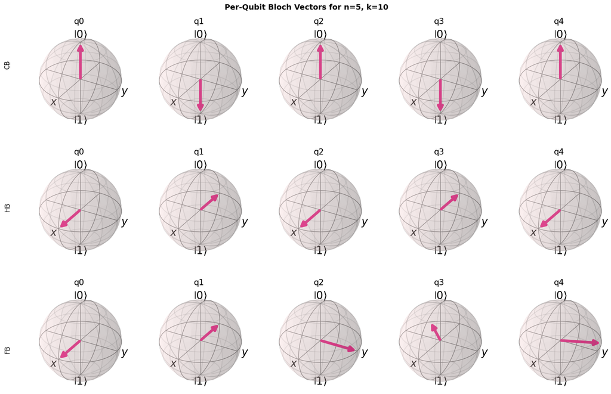

```python
# Example:
plot_bloch_grid(n=5, k=10)
```

Next, we animate the Bloch spheres in the Fourier basis as $k$ increases $k = 0, 1, \ldots, 2^n - 1.$

Each frame visualizes the state $\QFT \left( |k\rangle \right)$ and it is interesting to observe that every qubit's Bloch vector changes direction at each increment of $k$ compared to the previous one.

```python
from qiskit.visualization.state_visualization import plot_bloch_multivector
from PIL import Image
# from IPython.display import Image as ShowImage, display

# -------- params --------
n = 4
N = 2**n
duration_ms = 1200   # ms per frame (increase to slow down)
hold_each = 1

# -------- render frames --------
frames = []
for k in range(N):
    qc = QuantumCircuit(n)
    for i, bit in enumerate(format(k, f'0{n}b')[::-1]):  # little-endian prep (q0 = LSB)
        if bit == '1':
            qc.x(i)
    qc.append(QFT(n, do_swaps=True), range(n))

    fig = plot_bloch_multivector(Statevector(qc).data)
    fig.suptitle(f"Fourier-basis Bloch spheres for k = {k} (bin {format(k, f'0{n}b')})", fontsize=12)
    fig.canvas.draw()
    buf = np.asarray(fig.canvas.buffer_rgba())[:, :, :3]
    frame = Image.fromarray(buf)
    frames.extend([frame] * hold_each)
    plt.close(fig)

# -------- save GIF + show inline --------
# gif_path = "qft_bloch.gif"
# frames[0].save(gif_path, save_all=True, append_images=frames[1:], duration=duration_ms, loop=0)
# display(ShowImage(filename=gif_path))
```

[figure not shown]

## Implementation of QFT

Suppose we have the integer $k$ and we want to obtain

$$\mathrm{QFT}|k\rangle.$$

How can this be achieved in practice? What does the circuit that implements the QFT look like? That is what we will explore next.

First, we focus on the gates required to implement the $\QFT$:

### Gates used in a QFT circuit

1. **Hadamard gates** $H$ on each qubit $$ H=\frac{1}{\sqrt{2}}\begin{bmatrix}1&1\\ 1&-1\end{bmatrix}. $$
2. **Controlled phase rotations** between a control qubit $c$ and a target qubit $t$

*Before introducing the controlled version, note that several closely related gates connect in this context. We’ll start with the single-qubit phase gate, relate it to $\mathrm{RZ}$, and then lift it to the controlled form.*

**Phase Shift (single qubit)**

First, recall the single-qubit phase shift: $$ \mathrm{PhaseShift}(\theta)= \begin{bmatrix} 1 & 0\\[2pt] 0 & e^{i\theta} \end{bmatrix}. $$

- PennyLane: [`qml.PhaseShift`](https://docs.pennylane.ai/en/stable/code/api/pennylane.PhaseShift.html)
- Qiskit: [`PhaseGate`](https://quantum.cloud.ibm.com/docs/en/api/qiskit/qiskit.circuit.library.PhaseGate)
- Common notation: $\mathrm{P}(\theta)$

**Relation to $RZ$:**

It is related to the $\mathrm{RZ}$ rotation: $$ \mathrm{RZ}(\theta)=e^{\frac{-i\theta Z}{2}}= \begin{bmatrix} e^{\frac{-i \theta}{2}} & 0\\ 0 & e^{\frac{i\theta}{2}} \end{bmatrix}, \qquad \mathrm{PhaseShift}(\theta)=e^{\frac{\theta}{2}} RZ(\theta). $$

- PennyLane: [`qml.RZ`](https://docs.pennylane.ai/en/stable/code/api/pennylane.RZ.html)
- Qiskit: [`RZGate`](https://quantum.cloud.ibm.com/docs/en/api/qiskit/qiskit.circuit.library.RZGate)
- Common notation: $\mathrm{RZ}(\theta)$

**Controlled phase shift (two qubits):**

The natural two-qubit generalization is the controlled phase shift: apply the same phase only when the control qubit is $|1\rangle$. $$ \mathrm{ControlledPhaseShift}(\theta)= \mathrm{diag}(1,\,1,\,1,\,e^{i\theta}). $$

- PennyLane: [`qml.ControlledPhaseShift`](https://docs.pennylane.ai/en/stable/code/api/pennylane.ControlledPhaseShift.html)
- Qiskit: [`CPhaseGate`](https://docs.quantum.ibm.com/api/qiskit/qiskit.circuit.library.CPhaseGate)

### General controlled rotations and their relation to phase shifts

Beyond phase shifts, QFT implementations often use generalized controlled rotations.

**PennyLane:**

- [`qml.CRot(phi, theta, omega)`](https://docs.pennylane.ai/en/stable/code/api/pennylane.CRot.html)

**Qiskit:**

- [`CUGate(theta, phi, lambda, gamma)`](https://quantum.ibm.com/docs/api/qiskit/qiskit.circuit.library.CUGate)
- `CU3Gate` is deprecated; [`CU3(theta, phi, lambda)`](https://quantum.cloud.ibm.com/docs/en/api/qiskit/qiskit.circuit.library.CU3Gate) `=` [`CU(theta, phi, lambda, 0)`](https://quantum.cloud.ibm.com/docs/en/api/qiskit/qiskit.circuit.library.CUGate)

Note: matrix forms in PennyLane vs Qiskit can differ due to parameter conventions and wire ordering (endianness and which wire is considered the control).

$$ \mathrm{CROT}(\phi, \theta, \omega) = \begin{bmatrix} 1 & 0 & 0 & 0\\ 0 & 1 & 0 & 0\\ 0 & 0 & e^{-i(\phi+\omega)/2}\cos\frac{\theta}{2} & -\,e^{\,i(\phi-\omega)/2}\sin\frac{\theta}{2}\\[6pt] 0 & 0 & e^{-i(\phi-\omega)/2}\sin\frac{\theta}{2} & \ \ e^{\,i(\phi+\omega)/2}\cos\frac{\theta}{2} \end{bmatrix}. $$

Define a phase on the control wire: $$ P_c(\alpha)=\mathrm{diag} \left(1, 1, e^{i\alpha}, e^{i\alpha} \right). $$

Then a controlled phase shift drops out directly from $\mathrm{CRot}$: $$ \mathrm{ControlledPhaseShift}(\phi+ \omega) = P_c \left(\frac{\phi+ \omega}{2} \right) \mathrm{CRot}(\phi, 0, \omega), $$ and the matrix check follows: $$ P_c \left(\frac{\phi+ \omega}{2}\right) \mathrm{CRot} (\phi,0,\omega) =\mathrm{diag} \left(1, 1, 1, e^{i(\phi+\omega)} \right). $$

This shows that the controlled phase shift is a simple special case of a generalized controlled rotation (up to a phase on the control wire).

- **Angles used in QFT:** at stage $j$ (operating on qubit $j$), each lower-index control $k<j$ applies a controlled phase with $$ \theta_{j,k} \;=\; \frac{\pi}{2^{\,j-k}} \;=\; \frac{2\pi}{2^{\,j-k+1}}. $$
3. **(Optional) SWAP network** to reverse qubit order at the end:

$$ \mathrm{SWAP} \;=\; \begin{bmatrix} 1 & 0 & 0 & 0\\ 0 & 0 & 1 & 0\\ 0 & 1 & 0 & 0\\ 0 & 0 & 0 & 1 \end{bmatrix}. $$

$$ \mathrm{SWAP}(0,n - 1),\ \mathrm{SWAP}(1,n - 2),\ \dots $$

Next, we will first look at the decomposition of the QFT circuit in PennyLane and then justifies it correctness.

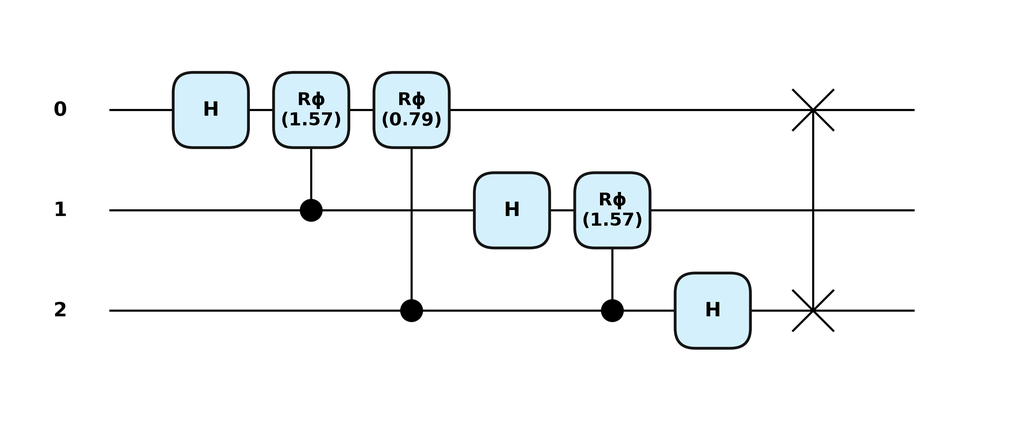

```python
# source: https://pennylane.ai/qml/demos/tutorial_qft
import pennylane as qml
from functools import partial

plt.style.use('pennylane.drawer.plot')

# This line is to expand the circuit to see the operators
@partial(qml.transforms.decompose, max_expansion=1)

def circuit():
    qml.QFT(wires=range(3))

qml.draw_mpl(circuit, decimals=2, style = "pennylane")()
plt.show()
```

The general textbook QFT is provided by the following circuit in the following order on each wire:

For each wire $m=0, 1, \dots, n-1$:

1. Apply the Hadamard gate $H$ on wire $m$.
2. For every $j \in \{ m+1, m+2, \dots, n-1 \}$, apply a controlled phase shift $\mathrm{ControlledPhaseShift}(\theta_{j,m})$ with control wire $j$ and target on wire $m$ where $\theta_{j,m} = \frac{2 \pi}{2^{1+j-m}}$, yielding

$$\mathrm{ControlledPhaseShift}(\theta_{j,m})= \mathrm{diag}\left(1,1,1, e^{i \theta_{j,m}} \right) = \mathrm{diag}\left(1,1,1, e^{\frac{2 \pi i}{2^{1+j-m}}} \right) $$

After completing all $m$, apply:

$$ \prod_{k=0}^{\lfloor n/2 \rfloor - 1} \mathrm{SWAP}\big(k,\, n-1-k\big). $$

The correctness of the $\QFT$ on a 3-qubit system:

Let $N=2^n$ with $n=3$. Let $| \psi_0 \rangle = | x_1 x_2 x_3 \rangle $. We want to compute $\QFT\left( |\psi_0 \rangle \right)$:

1. Apply a Hadamard gate to $| x_1 \rangle $:

$$ | \psi_1 \rangle = H|x_1 \rangle \otimes |x_2 \rangle \otimes |x_3 \rangle = \frac{1}{\sqrt{2}} \left[ |0 \rangle + e^{\frac{2 \pi i x_1}{2}} |1 \rangle \right] \otimes | x_2 \rangle \otimes | x_3 \rangle. $$

2. Apply the $\mathrm{ControlledPhaseShift}(\theta_{2,1})$ gate on qubit 1 controlled by qubit 2:

$$ | \psi_2 \rangle = \frac{1}{\sqrt{2}} \left[ |0 \rangle + e^{2 \pi i \left( \frac{x_1}{2} + \frac{x_2}{2^2} \right)} |1 \rangle \right] \otimes | x_2 \rangle \otimes | x_3 \rangle $$

3. Apply the $\mathrm{ControlledPhaseShift}(\theta_{3,1})$ gate on qubit 1 controlled by qubit 3:

$$ | \psi_3 \rangle = \frac{1}{\sqrt{2}} \left[ |0 \rangle + e^{2 \pi i \left( \frac{x_1}{2} + \frac{x_2}{2^2} + \frac{x_3}{2^3} \right)} |1 \rangle \right] \otimes |x_2 \rangle \otimes | x_3 \rangle $$

4. Apply Hadamard gate to $|x_2 \rangle$:

$$ | \psi_4 \rangle = \frac{1}{\sqrt{2}} \left[ |0 \rangle + e^{2 \pi i \left( \frac{x_1}{2} + \frac{x_2}{2^2} + \frac{x_3}{2^3} \right)} |1 \rangle \right] \otimes \frac{1}{\sqrt{2}} \left[| 0 \rangle + e^{\frac{2 \pi i x_2}{2}} |1\rangle \right] \otimes \ | x_3 \rangle $$

5. Apply the $\mathrm{ControlledPhaseShift}(\theta_{3,2})$ gate on qubit 2 controlled by qubit 3:

$$ | \psi_5 \rangle = \frac{1}{\sqrt{2}} \left[ |0 \rangle + e^{2 \pi i \left( \frac{x_1}{2} + \frac{x_2}{2^2} + \frac{x_3}{2^3} \right)} |1 \rangle \right] \otimes \frac{1}{\sqrt{2}} \left[| 0 \rangle + e^{2 \pi i \left( \frac{x_2}{2} + \frac{x_3}{2^2} \right) } |1\rangle \right] \otimes | x_3 \rangle $$

6. Apply Hadamard gate to $|x_3 \rangle$:

$$ | \psi_6 \rangle = \frac{1}{\sqrt{2}} \left[ |0 \rangle + e^{2 \pi i \left( \frac{x_1}{2} + \frac{x_2}{2^2} + \frac{x_3}{2^3} \right)} |1 \rangle \right] \otimes \frac{1}{\sqrt{2}} \left[| 0 \rangle + e^{2 \pi i \left( \frac{x_2}{2} + \frac{x_3}{2^2} \right) } |1\rangle \right] \otimes \frac{1}{\sqrt{2}} \left[ | 0 \rangle + e^{\frac{2 \pi i x_3}{2}} | 1 \rangle \right] $$

7. Apply SWAP gate to swap qubits 1 and 3. Then:

$$ \QFT \left( |x_1x_2x_3 \rangle \right) = \frac{1}{\sqrt{8}} \left[ \left( | 0 \rangle + e^{\frac{2 \pi i x_3}{2}} | 1 \rangle \right) \otimes \left( | 0 \rangle + e^{2 \pi i \left( \frac{x_2}{2} + \frac{x_3}{2^2} \right) } |1\rangle \right) \otimes \left( |0 \rangle + e^{2 \pi i \left( \frac{x_1}{2} + \frac{x_2}{2^2} + \frac{x_3}{2^3} \right)} |1 \rangle \right) \right] $$

### Gate complexity of the exact QFT

Next, we consider the gate complexity of the exact $\QFT$.

- There are $n$ Hadamard gates, one per qubit.
- There are up to $\lfloor n/2 \rfloor$ optional $\mathrm{SWAP}$ gates to undo bit-reversal.

There are $n$ applications of Hadamards, one for each gate. Furthermore, there are $\lfloor \frac{n}{2} \rfloor$ optionals $\mathrm{SWAP}$ gates.

The asymptotic cost is dictated by the controlled phase shifts. For qubit $m \in \{1,\dots,n \}$, there is one controlled phase shift from each more-significant qubit. That is, $n-m$ in total, per qubit. Concretely:

- qubit $1$: $n-1$ controlled phase shifts
- qubit $2$: $n-2$
- $\vdots$
- qubit $n-1$: $1$
- qubit $n$: $0$

Total count: $$ (n-1) + (n-2) + \cdots + 1 = \frac{n(n-1)}{2}. $$

Hence the exact $\QFT$ uses $\frac{n(n-1)}{2}$ controlled phase shifts $+ n$ Hadamards $+ \lfloor n/2\rfloor$ SWAPs, so the gate complexity is $\mathcal{O}(n^2)$, dominated by the controlled phase shifts.

### QFT Approximations

The exact $\mathrm{QFT}$ on $n$ qubits uses $\mathcal{O}(n^2)$ controlled-phase rotations. A practical approximation reduces this cost by dropping the smallest-angle controlled phases, trading a small error for fewer gates.

Further reading:

- $\mathcal{O}(n \log n)$ $T$-count approximation of $\mathrm{QFT}$: https://www.nature.com/articles/s41534-020-0257-5
- $\mathcal{O}\left(n \log(\frac{n}{\epsilon})\right)$ for approximate $\mathrm{QFT}$ modulo 2: https://arxiv.org/pdf/quant-ph/0006004

### Complexity of QFT vs Classical Fourier Transform

The $\QFT$ is the quantum counterpart of the classical Fourier transform, for which the fast Fourier transform (FFT) provides an efficient classical implementation (developed by James William Cooley and John Wilder Tukey, see [Cooley-Tukey FFT algorithm](https://en.wikipedia.org/wiki/Cooley%E2%80%93Tukey_FFT_algorithm)).

For an input of size $N = 2^n$, the FFT runs in time $$ \mathcal{O} (N \log N) = \mathcal{O} (2^n n) $$ which is exponential in the number of qubits $n$.

On the other hand, the textbook $\QFT$ can be implemented with $\mathcal{O}(n^2)$ quantum gates. Comparing these two, $$ \frac{2^n n}{n^2} = \frac{2^n}{n} $$ shows that $\QFT$ achieves an exponential speedup when the input size is measured in $n$.

### Mutually Unbiased Bases

Next, we briefly introduce the concept of mutually unbiased bases. To illustrate this, let us consider 2-qubit states in the computational basis and express them in the Hadamard basis and the $\QFT$ basis.

$|00 \rangle = \frac{1}{2} \left( | ++ \rangle + | +- \rangle + | -+ \rangle + | -- \rangle \right) = \frac{1}{2} \left( b_0 + b_1 + b_2 + b_3 \right)$

where each $b_i$ is a basis element in the $\QFT$ basis and defined as:

- $b_0 = \frac{1}{2} \left( |00 \rangle + |01 \rangle + |10 \rangle + |11\rangle \right) $
- $b_1 = \frac{1}{2} \left( |00 \rangle + i|01 \rangle - |10 \rangle -i |11\rangle \right) $
- $b_2 = \frac{1}{2} \left( |00 \rangle - |01 \rangle + |10 \rangle - |11\rangle \right) $
- $b_3 = \frac{1}{2} \left( |00 \rangle - |01 \rangle - |10 \rangle +i |11\rangle \right) $

The interesting observation is that if we take a computational basis state and express it in the Hadamard or $\QFT$ basis, the probability of measuring it back in the computational basis is always uniform. For example,

$$\left| \langle 00 | \frac{1}{2} \left( | ++ \rangle + | +- \rangle + | -+ \rangle + | -- \rangle \right) \right|^2 = \left| \langle 00 | \frac{1}{2} \left( b_0 + b_1 + b_2 + b_3 \right) \right|^2 = \frac{1}{4}.$$

This holds for any computational basis element expanded in the Hadamard or $\QFT$ basis: each outcome appears with equal probability. Hadamard and $\QFT$ are special in the sense that an arbitrary basis expanded against the computational one will not, in general, give uniform overlaps,

This concept, namely, the uniformity of overlaps between orthonormal basis elements, is formalized by the notion of mutually unbiased bases.

**Definition (Mutually Unbiased Bases)**

Two orthonormal bases $\{ |u_j\rangle \}_{j=1}^{d}$ and $\{ |v_k\rangle \}_{k=1}^d$ of a $d$-dimensional Hilbert space are said to be mutually unbiased if

$$ \left| \langle u_j | v_k \rangle \right|^2 = \frac{1}{d}, \quad \forall j,k. $$

In other words, if a system is prepared in a state from one basis, its expansion in the other basis has equal magnitude across all basis elements.

Interestingly, the maximum number of mutually unbiased bases (MUBs) in a given dimension $d$ is not known in general as it remains an open problem. If $d$ is a prime power, that is $d=p^n$ for some prime $p$ and integer $n$, then there exist exactly $d+1$ MUBs. For dimensions that are not prime powers, the maximum number is unknown. In particular, for $d=6$, only three MUBs have been constructed; it is generally believed that three is the maximum, but this has not been proven. For further details, see https://en.wikipedia.org/wiki/Mutually_unbiased_bases#Existence_problem.

#### Reminder on $\QFT$ notation

While we have expressed the $\QFT$ basis elements in the computational basis, in the literature it is customary to use a tilde notation (e.g. $|\tilde{j} \rangle )$, as stated earlier, to signify that the state belongs to the $\QFT$ basis rather than the computational basis. Thus, for two-qubit systems:

- $|\tilde{0} \rangle = \frac{1}{2} \left( |00 \rangle + |01 \rangle + |10 \rangle + |11\rangle \right)$
- $|\tilde{1} \rangle = \frac{1}{2} \left( |00 \rangle + i|01 \rangle - |10 \rangle -i |11\rangle \right) $
- $|\tilde{2} \rangle = \frac{1}{2} \left( |00 \rangle - |01 \rangle + |10 \rangle - |11\rangle \right) $
- $|\tilde{3} \rangle = \frac{1}{2} \left( |00 \rangle - |01 \rangle - |10 \rangle +i |11\rangle \right) $

### Example

To see an implementation of the $\QFT$ in practice, we will consider a quantum state with periodic amplitudes and demonstrate how the $\QFT$ can be applied to extract the underlying periodicity. This example is adapted from [this PennyLane tutorial](https://pennylane.ai/qml/demos/tutorial_qft) by Guillermo Alonso, with some modifications.

The idea is to prepare the state $$ | \psi \rangle = \frac{1}{\sqrt{32}} \sum\limits_{x=0}^{31} \exp \left( \frac{-2 \pi i x}{10} \right) | x \rangle, $$ which has a period of $10$.

The first step invovles preparing the state, which is not a trivial task.

### Example 1: Baseline Circuit (No Ancilla)

First we create a uniform superposition of all the states by applying Hadamard gates on all the wires:

$$H^{\otimes 5} |0\rangle^{\otimes 5} = \frac{1}{\sqrt{32}} \sum\limits_{x=0}^{31} |x\rangle $$

We can express $x$ in binary as $x= x_0 + 2x_1 + 4x_2 + 8x_3 + 16x_4$.

Next we want every basis element $|x\rangle$ to pick up a phase shift of $\exp \left( \frac{-2 \pi i x}{10} \right)$. Equivalently: $$ \exp\left( \frac{- 2 \pi i x}{10} \right) = \exp \left( \frac{-2 \pi i x_0}{10} \right) \cdot \exp \left( \frac{-2 \pi i (2x_1)}{10} \right) \cdot \exp \left( \frac{-2 \pi i (4x_2)}{10} \right) \cdot \exp \left( \frac{-2 \pi i (8x_3)}{10} \right) \cdot \exp \left( \frac{-2 \pi i (16x_4)}{10} \right). $$

Hence, the action of each term $$\left\{ \exp\left( \frac{-2\pi i (2^j x_{j})}{10} \right) \right\}_{j=0}^4$$ can be implemented by $$\left\{ \mathrm{PhaseShift}\left( \frac{ -2 \pi \cdot 2^{j} }{10} \right) \right\}_{j=0}^4.$$

Note that the standard QFT circuit, before the final SWAP layer, produces its outputs in bit-reversed order. To align with that convention, the exponents of $2$ must be assigned in reversed order. That is, $$ \left\{ \mathrm{PhaseShift} \left( \frac{-2 \pi 2^{4-j}}{10} \right) \right\}_{j=0}^4. $$

However, if the goal is purely to prepare the state $ | \psi \rangle = \frac{1}{\sqrt{32}} \sum\limits_{x=0}^{31} \exp \left( \frac{-2 \pi i x}{10} \right) | x \rangle, $, then the direct construction with $\mathrm{PhaseShift(-2 \pi \cdot 2^{j} / 10)}$ on qubit $j$ is already correct.

Next, we will prepare this state in PennyLane. Note that we will not make use of an ancilla qubit in this implementation, unlike in the PennyLane tutorial. We will cover that case briefly afterwards.

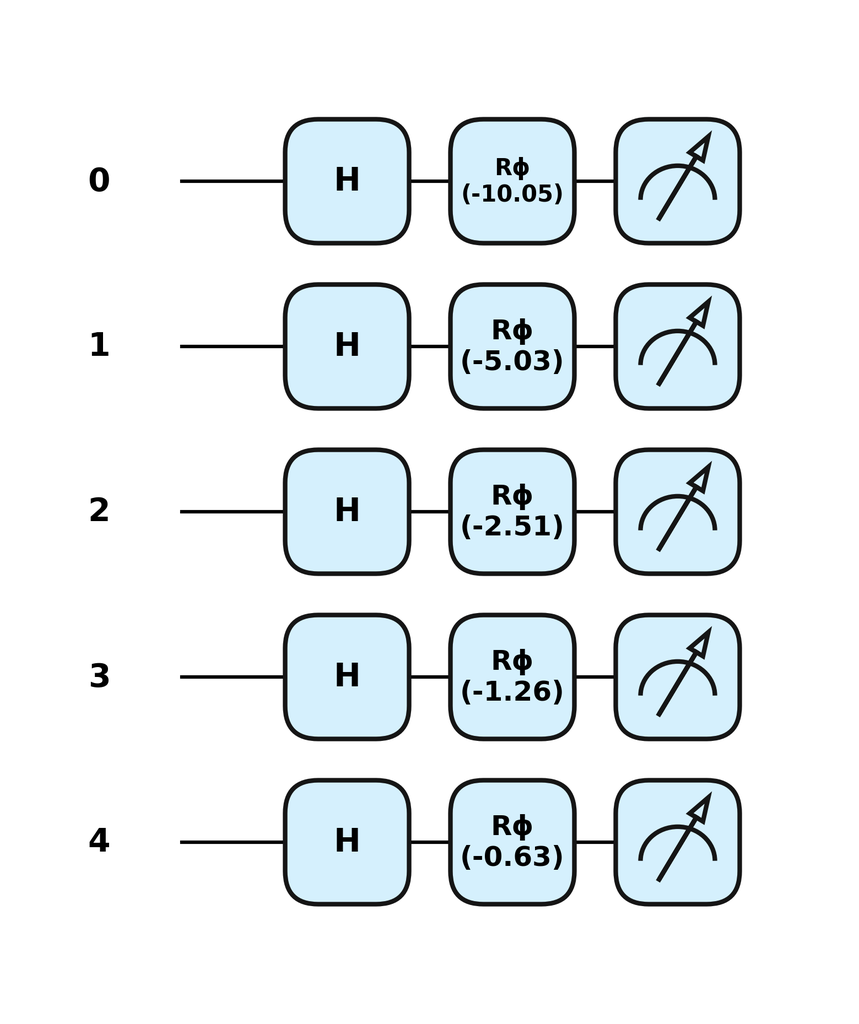

```python
n_qubits = 5
period = 10

def prep_no_ancilla():
    # 1) Uniform superposition
    for wire in range(n_qubits):
        qml.Hadamard(wires=wire)

    # 2) Per-bit phase shifts with descending powers of two
    for wire in range(n_qubits):
        pow2 = 2**(n_qubits - 1 - wire)
        angle = -2 * np.pi * pow2 / period
        qml.PhaseShift(angle, wires=wire)

dev = qml.device("default.qubit", wires=n_qubits)
@qml.qnode(dev)
def circuit_state_no_ancilla():
    prep_no_ancilla()
    return qml.state()

qml.draw_mpl(circuit_state_no_ancilla, decimals=2, style = "pennylane")()
plt.show()
```

$$ \newcommand{\Real}{\operatorname{Re}} \newcommand{\Imag}{\operatorname{Im}} $$

Before applying the $\QFT$ to the state, note that measuring the state $ | \psi \rangle = \frac{1}{\sqrt{32}} \sum\limits_{x=0}^{31} \exp \left( \frac{-2 \pi i x}{10} \right) | x \rangle, $ in the computational basis does not reveal insightful information about the period. This is because the probability of each basis state is equal to $\frac{1}{32}$, given by the squared magnitude of the amplitudes: $$ P(x) = \left| \frac{1}{\sqrt{32}} \exp \left( \frac{-2 \pi i x}{10} \right) \right|^2 = \frac{1}{32} $$ Hence, the measurement produces a uniform distribution.

That said, the real and imaginary parts of the amplitudes still carry the periodic information of the state $|\psi\rangle$.

Each amplitude is given by $$ \psi(x) = \frac{1}{\sqrt{32}} \exp \left( \frac{-2 \pi i x}{10} \right) = \frac{1}{\sqrt{32}} \left( \cos \left( \frac{2 \pi x}{10} \right) - i \sin \left( \frac{2 \pi x}{10} \right) \right) $$ with real and imaginary parts $$ \Real [ \psi(x) ] = \frac{1}{\sqrt{32}} \cos \left( \frac{2 \pi x}{10} \right), \qquad \Imag [ \psi(x) ] = -\frac{1}{\sqrt{32}} \sin \left( \frac{2 \pi x}{10} \right). $$

When computing the probabilities $P(x) = \frac{1}{32} \left( \cos^2 \frac{2\pi x}{10} + \sin^2 \frac{2 \pi x}{10} \right),$ we can use the Pythagorean identity $\cos^2 \theta + \sin^2 \theta = 1$. This gives $P(x) = \frac{1}{32}.$ In other words, the squared contributions of the real and imaginary parts always add up to 1, so the measurement distribution is uniform over all basis states, with each outcome occurring with probability $\frac{1}{32}$. The oscillations in the real and imaginary parts cancel in the squared magnitude, leaving no variation between different outcomes. So the periodic information is "hidden in the phases", and the computational-basis measurement can’t access it. The rules of quantum mechanics does not allow one to access real and imaginary components individually, otherwise, we could have extracted the period from the directly.

By applying $\QFT$, the periodicity appears in the measurement distribution. That's why QFT is needed to reveal the period.

Before applying the $\QFT$, we plot the real and imaginary components of the amplitudes, together with the probability distribution of the state in the computational basis.

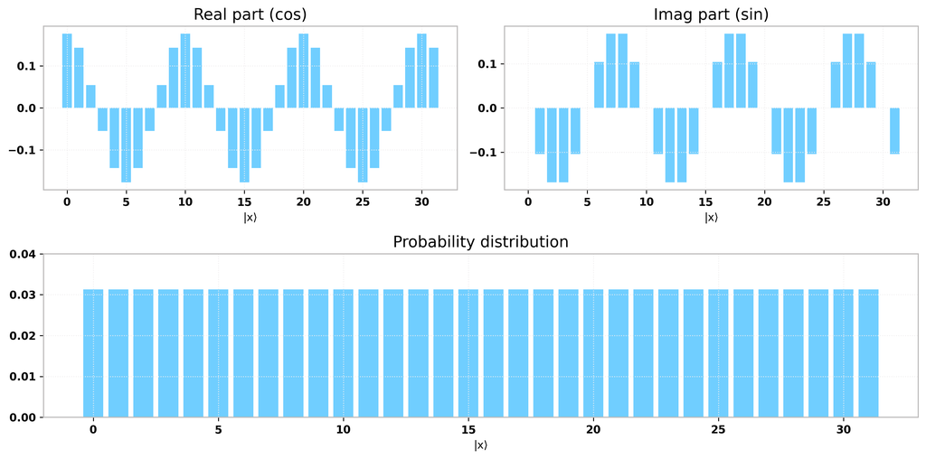

```python
amps = circuit_state_no_ancilla()

plt.figure(figsize=(12,6))

# Top-left: real part
plt.subplot(2,2,1)
plt.bar(range(len(amps)), amps.real)
plt.title("Real part (cos)")
plt.xlabel("|x⟩")

# Top-right: imaginary part
plt.subplot(2,2,2)
plt.bar(range(len(amps)), amps.imag)
plt.title("Imag part (sin)")
plt.xlabel("|x⟩")

# Bottom: probabilities (span both columns)
plt.subplot(2,1,2)
plt.bar(range(len(amps)), np.abs(amps)**2)
plt.title("Probability distribution")
plt.xlabel("|x⟩")
plt.ylim(0,0.04)

plt.tight_layout()
plt.show()
```

Next, we will apply the $\QFT$ to extract the period of the state $| \psi \rangle$. Ideally, one would hope that the result of the measurement reveals the period directly; however, that is not the case. Therefore, it is important to understand what the output of the measurements are so we can better undrestand and prepare for post-measurement process.

Let's consider the general case, where we prepare an $n$-qubit periodic state with period $r$, $0 < r < 2^n$ and $N = 2^n$: $$ |\psi \rangle = \frac{1}{\sqrt{N}} \sum\limits_{x=0}^{N-1} \exp{\left( \frac{- 2\pi i x}{r} \right)} | x \rangle, $$ In our case, $N=32$ and $r=10$.

Recall:

The $\QFT$ is a unitary operation that maps the computational basis state $|x\rangle $ to:

$$ \QFT(|x\rangle) = \frac{1}{\sqrt{N}} \sum\limits_{y=0}^{N-1} e^{\frac{2 \pi i \cdot xy}{N}} |y\rangle $$

Applying the $\QFT$:

$$ \QFT |\psi \rangle = \frac{1}{\sqrt{N}} \sum\limits_{x=0}^{N-1} \exp{\left( \frac{- 2\pi i x}{r} \right)} \QFT \left( | x \rangle \right) $$

Hence, $$ \begin{aligned} \QFT |\psi \rangle &= \frac{1}{N} \sum\limits_{x=0}^{N-1} \left[ \sum\limits_{y=0}^{N-1} \exp\left( 2 \pi i x \left( \frac{y}{N} - \frac{1}{r} \right) \right) \right] | y \rangle \\ &= \frac{1}{N} \sum\limits_{y=0}^{N-1} \left[ \sum\limits_{x=0}^{N-1} \exp\left( 2 \pi i x \left( \frac{y}{N} - \frac{1}{r} \right) \right) \right] | y \rangle \end{aligned} $$

We recogonize the innter sum $$ \sum\limits_{x=0}^{N-1} \exp\left( 2 \pi i \left( \frac{y}{N} - \frac{1}{r} \right) \right)^x $$ as a finite geometric series.

Recall:

$$ a + ar + ar^2 + \dots + ar^n = \sum\limits_{k=0}^n ar^k = a\frac{1 - r^{n+1}}{1-r} $$

Hence, $$ \sum\limits_{x=0}^{N-1} \exp\left( 2 \pi i \left( \frac{y}{N} - \frac{1}{r} \right) \right)^x = \frac{1 - e^{2 \pi i N \left( \frac{y}{N} - \frac{1}{r} \right)}}{1 - e^{ 2\pi i \left( \frac{y}{N} - \frac{1}{r} \right) }} $$ Hence, $$ \begin{aligned} \QFT |\psi \rangle &= \sum\limits_{y=0}^{N-1} \frac{1}{N} \frac{1 - e^{2 \pi i N \left( \frac{y}{N} - \frac{1}{r} \right)}}{1 - e^{ 2\pi i \left( \frac{y}{N} - \frac{1}{r} \right) }} |y\rangle \\ &= \sum\limits_{y=0}^{N-1} \alpha_y | y \rangle \end{aligned} $$ where $ \alpha_y = \frac{1}{N} \cdot \frac{1 - e^{2 \pi i N \left( \frac{y}{N} - \frac{1}{r} \right) }}{1 - e^{2 \pi i \left( \frac{y}{N} - \frac{1}{r} \right) } } $

Let $\theta = 2 \pi \left( \frac{y}{N} - \frac{1}{r} \right)$. Then $\alpha_y = \frac{1}{N} \cdot \frac{1 - e^{i N \theta}}{1 - e^{i \theta}}$.

Next we will derive the following equality:

$$ 1 - e^{i \theta} = -2 i e^{\frac{\theta}{2}} \sin\left( \frac{\theta}{2} \right) $$

Proof:

From a variant of Euler's formula, we know: $$ \sin(x) = \frac{e^{ix} - e^{-ix}}{2i} $$ Rearranging: $$ \begin{aligned} & 2i \sin(x) = e^{ix} - e^{-ix} \\ \Rightarrow & -2 i \sin(x) = e^{-ix} - e^{ix} \\ \Rightarrow & \frac{-2 i \sin(x)}{e^{-ix}} = 1 - \frac{e^{ix}}{e^{-ix}} \\ \Rightarrow & -2 i \sin(x)e^{ix} = 1 - e^{2ix} \end{aligned} $$ Let $2x = \theta$, it follows that: $$ 1 - e^{i \theta} = -2i e^{\frac{\theta}{2}} \sin\left(\frac{\theta}{2}\right) $$

Using the above identity, we can rewrite $\alpha_y$ as: $$ \begin{aligned} \alpha_y &= \frac{1}{N} \cdot \frac{1 - e^{i N \theta}}{1 - e^{i \theta}} \\ &= \frac{1}{N} \cdot \frac{-2i e^{\frac{iN \theta}{2}} \sin \left( \frac{N \theta}{2} \right)}{ -2i e^{\frac{i \theta}{2}} \sin \left( \frac{\theta}{2} \right) } \\ &= \frac{1}{N} \cdot e^{i (N -1 )\frac{\theta}{2}} \cdot \frac{\sin \left( \pi \left( y - \frac{N}{r} \right) \right) }{ \sin\left(\pi \left( \frac{y}{N} - \frac{1}{r} \right) \right) } \end{aligned} $$

The exponential factor $e^{i (N -1 )\frac{\theta}{2}}$ has mangintude $1$. It follows:

$$ \left| \alpha_y \right|^2 = \frac{1}{N^2} \cdot \frac{\sin^2 \left( \pi \left( y - \frac{N}{r} \right) \right) }{\sin^2 \left( \pi \left( \frac{y}{N} - \frac{1}{r} \right) \right)} $$

Note the numerator vanishes at $$\sin^2 \left( \pi \left( y - \frac{N}{r} \right) \right) = 0 \Rightarrow y - \frac{N}{r} = 0 \quad \Rightarrow \quad y = \frac{N}{r},$$ while the denominator vanishes at $$\sin^2 \left( \pi \left( \frac{y}{N} - \frac{1}{r} \right) \right) = 0 \quad \Rightarrow \quad \frac{y}{N} - \frac{1}{r} = 0 \Rightarrow \frac{y}{N} = \frac{1}{r} \Rightarrow y = \frac{N}{r}.$$

Therefore, at $y = \frac{N}{r}$ we obtain the indeterminate form $0/0$.

Recall, $$| \alpha_y | = \left| \frac{1}{N} \cdot \frac{\sin \left( \frac{N \theta}{2} \right)}{\sin \left( \frac{\theta}{2} \right) } \right|, \quad \theta = 2 \pi \left( \frac{y}{N} - \frac{1}{r} \right).$$ Taking the limit $\theta \rightarrow 0$ and applying the small-angle expansion gives $\sin\left( \frac{N \theta}{2} \right) \rightarrow \frac{N \theta}{2}$ and $\sin\left( \frac{\theta}{2} \right) \rightarrow \frac{\theta}{2}$. Hence $|\alpha_y| = |\frac{N}{N}| = 1 \Rightarrow |\alpha_y|^2 = 1$ when $y = \frac{N}{r}$.

This argument is valid when treating $|\alpha_y|$ as a continuous function of $y$. However, measurement outcomes are restricted to the discrete set $\{ 0,1, \dots, N-1 \}$. Thus, an exact peak occurs at $y = \frac{N}{r}$ when $r \mid N$.

If $r \not\mid N$, then $\frac{N}{r} \not\in \mathbb{Z}$. In that case the distribution still has continuous maximum at $y = \frac{N}{r}$, but since this point is not an integer, the observed outcomes concentrate around the nearest integers $y \approx \frac{N}{r}$. The largest probability mass is typically on $y = \text{round}\left( \frac{N}{r} \right)$, with smaller mass on neighbouring bins, and the sidelobes decay quickly. Over many runs the expectation value still clusters around $\frac{N}{r}$.

The distribution $$\frac{1}{N^2} \cdot \frac{\sin^2 \left( \pi \left( y - \frac{N}{r} \right) \right) }{\sin^2 \left( \pi \left( \frac{y}{N} - \frac{1}{r} \right) \right)}$$ closely resembles [Fejér kernel](https://en.wikipedia.org/wiki/Fej%C3%A9r_kernel), which is not a coincidence. For more information, refer to [Properties of The Discrete Sinc Quantum State and Applications to Measurement Interpolation](https://arxiv.org/pdf/2207.00564).

Hence, the theory suggests that for $N = 32$ and $r = 10$, the peak occurs at $x \approx 3.2$, with the integer $x = 3$ being the most likely measurement outcome.

An interactive visualization of this function can be explored on Desmos: https://www.desmos.com/calculator/qxrh3tqbkg

We now apply the $\QFT$ circuit to the prepared state and plot the real part, imaginary part, amplitude magnitude, and probability distribution. Note that for values of $x$ beyond $3$, the probabilities are non-zero; however, since they are relatively small, they may not be visually apparent.

```python
@qml.qnode(dev)
def circuit_qft_probs_no_ancilla():
    prep_no_ancilla()
    qml.QFT(wires=range(n_qubits))
    # return qml.probs(wires=range(n_qubits))
    return qml.state()
```

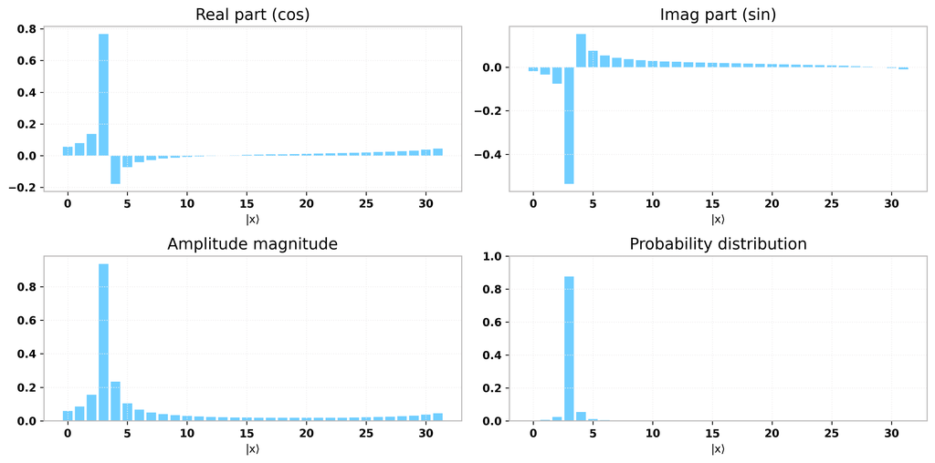

```python
amps = circuit_qft_probs_no_ancilla()

plt.figure(figsize=(12,6))

# Top-left: real part
plt.subplot(2,2,1)
plt.bar(range(len(amps)), amps.real)
plt.title("Real part (cos)")
plt.xlabel("|x⟩")

# Top-right: imaginary part
plt.subplot(2,2,2)
plt.bar(range(len(amps)), amps.imag)
plt.title("Imag part (sin)")
plt.xlabel("|x⟩")

# Magnitude |amplitude|
plt.subplot(2,2,3)
plt.bar(range(len(amps)), np.abs(amps))
plt.title("Amplitude magnitude")
plt.xlabel("|x⟩")

# Bottom: probabilities
plt.subplot(2,2,4)
plt.bar(range(len(amps)), np.abs(amps)**2)
plt.title("Probability distribution")
plt.xlabel("|x⟩")
plt.ylim(0,1)

plt.tight_layout()
plt.show()
```

If we compute the expected value, the result should be close to $3.2$

```python
probs = np.abs(amps)**2    # probabilities p_y
ys = np.arange(len(probs)) # indices 0..N-1
E = np.sum(ys * probs)
print(E)
```

```
3.3361553882398325
```

While it may not be exactly $3.2$, as it is in this case, it is indeed very close, which confirms our observation.

We also find that the most likely outcome is $3$, as expected.

```python
int(np.argmax(probs))
```

```
3
```

### Example 2: Ancilla-Based Construction

In the [PennyLane tutorial](https://pennylane.ai/qml/demos/tutorial_qft), the state $| \psi \rangle$ is prepared in a slightly different way. An ancilla qubit is introduced on the first wire, and [ControlledSequence gates](https://docs.pennylane.ai/en/stable/code/api/pennylane.ControlledSequence.html) are used. As described in the documentation, these gates "create a sequence of controlled gates raised to decreasing powers of 2."

To make this construction work, an $X$ gate is applied to the ancilla wire. This step prepares the qubit for the `ControlledSequence` gates because, by convention, controlled operations activate when the control qubit is in the state $|1\rangle$. Applying $X$ transforms the initial $|0\rangle$ state into $|1\rangle$, ensuring the controlled sequence acts as intended.

The second $X$ gate is used to reset the system qubit back to the $|0\rangle$ state after the phase kickback has occurred. By convention, wire $0$ is the most significant bit (MSB) in PennyLane's state vector ordering, so the state can be written as:

$$ | \psi \rangle = \sum\limits_{x=0}^{N-1} a_{0,x} |0\rangle \otimes |x\rangle + \sum\limits_{x=0}^{N-1} a_{1,x} |1\rangle \otimes |x \rangle. $$

Hence, the first $2^n$ entries of the state vector correspond to indices $|0\rangle \otimes |x\rangle$, while the last $2^n$ entries correspond to $|1\rangle \otimes |x\rangle$. This is why, when plotting the amplitudes, we will retrieve the first $N$ values as they correspond to the $|0\rangle$ block. If the second $X$ is not applied, then the system remains in $|1\rangle$, and we would need to retrieve the second block (the last $N$ entries).

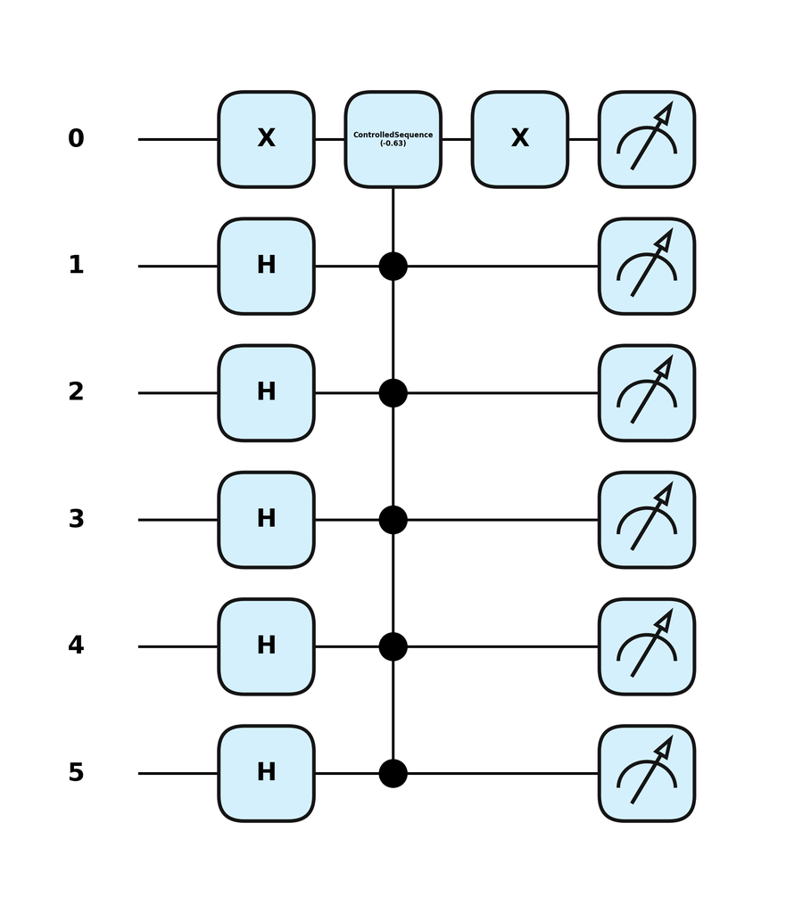

```python
n_qubits = 5
N = 2**n_qubits
period = 10

def prep():
    """quntum function that prepares the state."""
    qml.PauliX(wires=0)
    for wire in range(1, n_qubits+1):
        qml.Hadamard(wires=wire)
    qml.ControlledSequence(qml.PhaseShift(-2 * np.pi / period, wires=0), control=range(1,n_qubits+1)) # -2pi/10 ~= -0.63
    qml.PauliX(wires=0)

dev = qml.device("default.qubit", wires=n_qubits+1)
@qml.qnode(dev)
def circuit():
    prep()
    return qml.state()

qml.draw_mpl(circuit, decimals=2, style = "pennylane")()
plt.show()
```

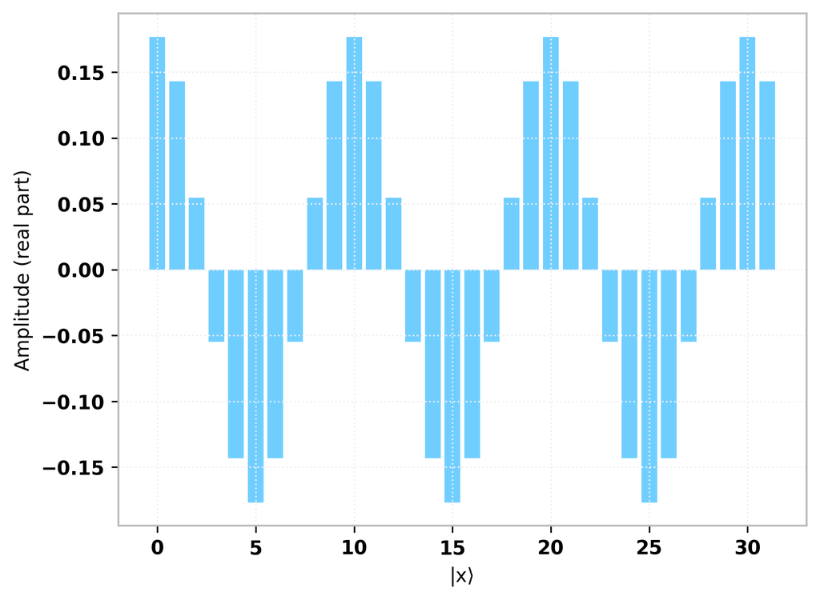

```python
state = circuit().real[:N]

plt.bar(range(len(state)), state)
plt.xlabel("|x⟩")
plt.ylabel("Amplitude (real part)")
plt.show()
```

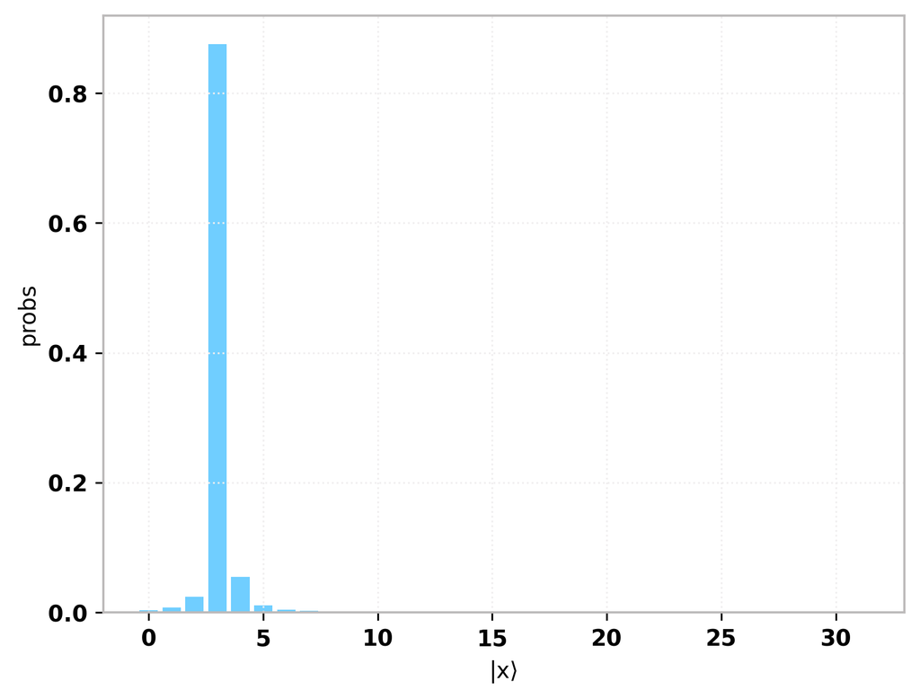

```python
@qml.qnode(dev)
def circuit():
  prep()
  qml.QFT(wires=range(1, n_qubits+1))

  return qml.probs(wires=range(1, n_qubits+1))

state = circuit()[:N]

plt.bar(range(len(state)), state)
plt.xlabel("|x⟩")
plt.ylabel("probs")
plt.show()
```

### Example 3: Alternative Parameters (6 Qubits, Period 16)

Lastly, to see another example, let us consider a slightly different setup now that we are familiar with the theory. We create a 6-qubit state with period 16. Note that $16 \mid 64 = 2^6$, and therefore, under perfect conditions, there should be a single bin with probability 1 at

$$ x = \frac{64}{16} = 4. $$

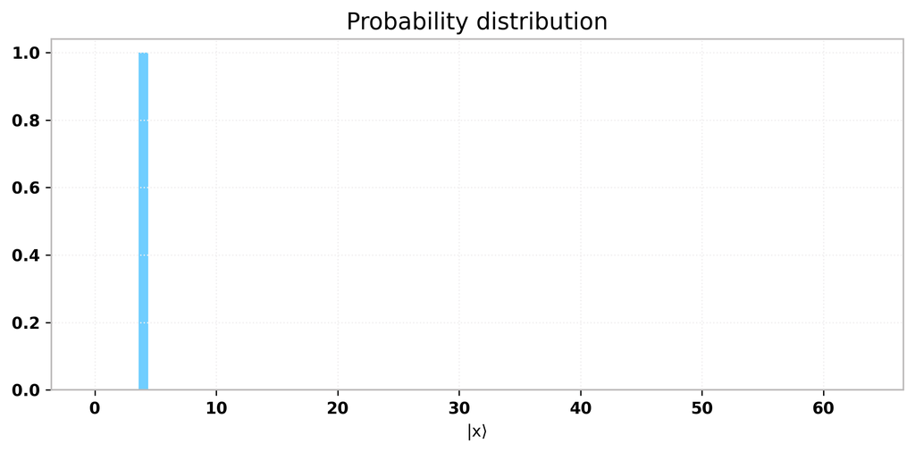

```python
n_qubits = 6
period = 16

def prep_no_ancilla():
    for wire in range(n_qubits):
        qml.Hadamard(wires=wire)

    for wire in range(n_qubits):
        pow2 = 2**(n_qubits - 1 - wire)
        angle = -2 * np.pi * pow2 / period
        qml.PhaseShift(angle, wires=wire)

dev = qml.device("default.qubit", wires=n_qubits)
@qml.qnode(dev)
def circuit_state_no_ancilla():
    prep_no_ancilla()
    return qml.state()

@qml.qnode(dev)
def circuit_qft_probs_no_ancilla():
    prep_no_ancilla()
    qml.QFT(wires=range(n_qubits))

    return qml.state()

amps = circuit_qft_probs_no_ancilla()

plt.figure(figsize=(8,4))

plt.bar(range(len(amps)), np.abs(amps)**2)
plt.title("Probability distribution")
plt.xlabel("|x⟩")
plt.ylim(0,1.04)

plt.tight_layout()
plt.show()
```

```python
(np.abs(amps)**2).argmax()
```

```
4
```

### Conclusion

We explored the quantum Fourier transform (QFT), defined the Fourier basis, and saw how the QFT maps a state into a basis that makes periodic structure explicit. The circuit uses Hadamards and controlled-phase gates and can be implemented with $\mathcal{O}(n^2)$ gates (or $\mathcal{O}(n \log (n))$ with approximations), and provides speedup over its classical counterpart. Although the QFT is a powerful theoretical primitive, central to algorithms like Shor’s, its practical implementation, particularly due to its depth, is challenging for NISQ hardware. That said, approximation methods can mitigate this.

Additionally, QFT-based algorithms typically rely on a highly structured, exact periodicity (e.g., the kind that appears in order-finding). A natural question is whether the QFT can be adapted to settings with weaker periodic structure, for example, in stock markets or seasonal weather patterns, where the signal is only approximately periodic. Exploring such "approximate periodicity" variants of the QFT, or QFT-inspired transforms, is an interesting direction. For example see

- [An efficient quantum algorithm for spectral estimation](https://arxiv.org/abs/1609.08170)
- [Short-time quantum Fourier transform processing](https://arxiv.org/abs/2504.20649)
- [Fourier series weight in quantum machine learning](https://arxiv.org/abs/2302.00105)
- [Efficient Quantum Algorithm for All Quantum Wavelet Transforms](https://arxiv.org/abs/2309.09350)

### Appendix 1: Biography

Peter Shor's algorithm for integer factorization, first published in the [Proceedings of the 35th Annual Symposium on Foundations of Computer Science in November 1994](https://ieeexplore.ieee.org/document/365700), made essential use of a quantum Fourier transform. In the 1994 conference version, Shor presented a construction based on smooth numbers. Around the same period, Don Coppersmith developed a more efficient approximate quantum Fourier transform that reduced the number of small phase rotations needed in the QFT step.

Shor cited Coppersmith's 1994 IBM Research Report in the expanded arXiv version of his paper:

> D. Coppersmith (1994), *An approximate Fourier transform useful in quantum factoring*, IBM Research Report RC 19642.

Coppersmith's report was dated June 1994 and was later posted publicly on arXiv in 2002 under the title [*An Approximate Fourier Transform Useful in Quantum Factoring*](https://arxiv.org/pdf/quant-ph/0201067). Its abstract explicitly describes the work as potentially useful for factoring integers on a quantum computer, then under investigation by Peter Shor. Thus, Shor's algorithm already used a quantum Fourier transform in 1994, while Coppersmith's work provided a more efficient approximate implementation that became part of the later expanded presentation of the algorithm.

Don Coppersmith is a mathematician and cryptographer who holds degrees from MIT and Harvard. His career includes work at IBM and later at the Institute for Defense Analyses (IDA) Center for Communications Research in Princeton. In 2022, his significant contributions were recognized with the [Levchin Prize for foundational innovations in cryptanalysis](https://rwc.iacr.org/LevchinPrize/winners.html#DonCoppersmith).

### Appendix 2: References and Suggested Readings

1. Coppersmith, Don. (1994/2002). *An Approximate Fourier Transform Useful in Quantum Factoring*. IBM Research Report RC19642. [arXiv:quant-ph/0201067](https://arxiv.org/pdf/quant-ph/0201067).
2. *Chapter 5: Quantum Fourier Transform*. UC Berkeley - BerkeleyX CS-191x course notes. Available at: https://d37djvu3ytnwxt.cloudfront.net/c4x/BerkeleyX/CS-191x/asset/chap5.pdf.
3. Datta, Nilanjana (2019–2020). *Quantum Information & Computation - Part IIC (Lent Term 2019–2020): The quantum Fourier transform and periodicities*. DAMTP (Department of Applied Mathematics and Theoretical Physics), University of Cambridge. Available at: https://www.qi.damtp.cam.ac.uk/files/QIC-10.pdf.
4. Alonso, Guillermo (2024). *Intro to Quantum Fourier Transform*. PennyLane Demos. Available at: https://pennylane.ai/qml/demos/tutorial_qft.
5. LaRose, Ryan. *Shor’s Algorithm Part 2: The Quantum Fourier Transform (QuIC Seminar 13)*. Available at: https://www.ryanlarose.com/uploads/1/1/5/8/115879647/shor2-qft.pdf.